# Лекция 10. DiD с разновременным включением

Блок 3. Отбор по ненаблюдаемым и естественные эксперименты

Карен Аванесян

Каузальный анализ в R на данных RLMS-HSE

# Зачем

## Политики приходят не одновременно

- Регионы вводят ограничения в разные годы; реформы поэтапны по когортам; программы раскатываются волнами
- Естественное желание: одна регрессия с двусторонними FE и индикатором «уже включено» — **TWFE**
- С 2018 г. выяснилось: при разных сроках включения и **меняющихся во времени** эффектах TWFE может дать число, не похожее ни на один настоящий эффект — вплоть до неверного знака

Проблема не в FE и не в DiD, а в том, **кого с кем** TWFE негласно сравнивает: уже обработанные единицы становятся «контролем» для включённых позже.

## План занятия

1. Декомпозиция Гудмана–Бэкона: из чего состоит TWFE
2. Запрещённые сравнения и отрицательные веса
3. Три исправления: Callaway–Sant’Anna, Sun–Abraham, импутация
4. Симуляция: все методы на одних данных
5. Как читать вывод `att_gt()`, `aggte()`, `sunab()` и писать результат
6. RLMS: когортное повышение пенсионного возраста
7. Чувствительность к предтрендам: `HonestDiD`

# Идея

## Декомпозиция Гудмана–Бэкона

Коэффициент TWFE $\hat\tau$ при $D_{it}$ — **взвешенное среднее всех 2 × 2 DiD**, которые можно составить из пар групп и периодов:

| Тип сравнения | Что служит контролем | Проблема |
| --- | --- | --- |
| обработанные vs никогда не обработанные | никогда не обработанные | нет |
| рано включённые vs поздно включённые (пока те не включены) | «ещё не обработанные» | нет |
| **поздно включённые vs рано включённые (уже обработанные)** | **уже обработанные** | **да** |

- Третий тип использует динамику эффекта у ранних как «тренд без воздействия»: если эффект **растёт**, он вычитается, и эффект поздних занижается — вплоть до смены знака

## Запрещённое сравнение в картинках

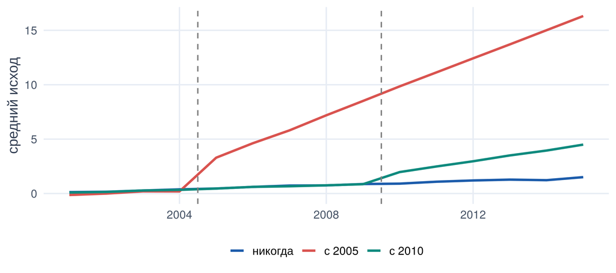

Сравнивая когорту 2010 с когортой 2005 после 2010 г., TWFE считает рост у «ранних» (их эффект продолжает расти) за общий тренд — и вычитает его.

## Три исправления

2021 · пакет `did`

### Callaway–Sant’Anna

Оценить $ATT(g, t)$ для каждой когорты $g$ и периода $t$, сравнивая **только** с никогда или ещё не обработанными; потом агрегировать

2021 · `fixest::sunab()`

### Sun–Abraham

Event study с взаимодействиями «когорта × относительное время» и взвешенным усреднением по когортам

2024 · `didimputation`

### Импутация (BJS)

Borusyak, Jaravel, Spiess: TWFE **только** на необработанных наблюдениях → предсказать $Y(0)$ для обработанных → усреднить разности

Для **обратимого** воздействия (включили — выключили): de Chaisemartin & D’Haultfœuille, `DIDmultiplegt`

При одинаковых эффектах все методы совпадают с TWFE. Расходятся — значит, эффекты гетерогенны, и TWFE нельзя доверять.

## Что значит «агрегировать»

Из $ATT(g, t)$ можно собрать разные ответы:

type =

### simple

Средний эффект по всем обработанным наблюдениям

type =

### dynamic

По времени с момента включения $k = t - g$: event study без запрещённых сравнений

type =

### group

По когортам: кому реформа помогла больше

type =

### calendar

По календарным годам

Каждый агрегат — отдельный эстиманд; «эффект политики» без уточнения — не ответ.

# Код

## Симуляция: три когорты, растущие эффекты

```r
panelview(y ~ d, data = as.data.frame(sim |> filter(id %% 20 == 0)), index = c("id", "year"),
          type = "treat", by.timing = TRUE, legend.labs = c("не обработан", "обработан"),
          main = "", xlab = "", ylab = "", axis.lab.gap = c(0, 10))
```

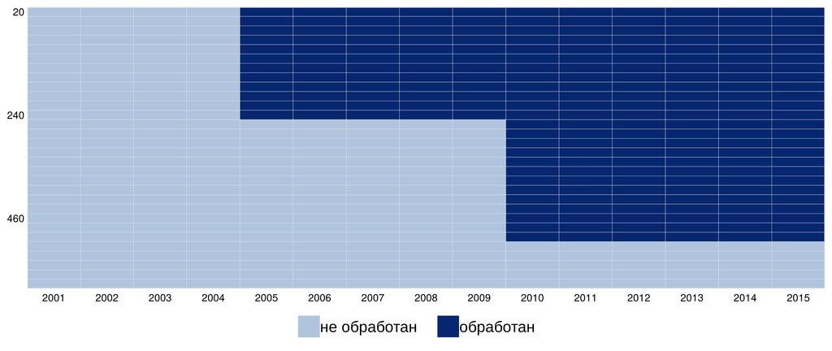

Эффект: у когорты 2005 — $3 \times (1 + 0.4k)$, у когорты 2010 — $1 \times (1 + 0.4k)$; никогда не обработанных — 100 из 600. Истинный ATT по всем обработанным наблюдениям: **6.53**.

## TWFE и декомпозиция

```r
twfe <- feols(y ~ d | id + year, data = sim, cluster = ~id)
c(`TWFE` = unname(coef(twfe)["d"]), `истина` = true_att)
```

```
  TWFE истина
  1.92   6.53
```

```r
bacon(y ~ d, data = as.data.frame(sim), id_var = "id", time_var = "year", quietly = TRUE) |>
  group_by(type) |> summarise(вес = sum(weight), оценка = weighted.mean(estimate, weight)) |>
  mutate(across(where(is.numeric), ~ round(.x, 2)))
```

| type | вес | оценка |
| --- | --- | --- |
| Earlier vs Later Treated | 0.22 | 5.36 |
| Later vs Earlier Treated | 0.34 | -4.63 |
| Treated vs Untreated | 0.44 | 5.18 |

- Треть веса — на сравнении «поздние vs ранние» с оценкой **−4.6** при истинных эффектах от 1 до 15
- Итог занижен втрое; при ещё более резкой динамике знак меняется

## Callaway–Sant’Anna

```r
cs <- att_gt(yname = "y", tname = "year", idname = "id", gname = "g",
             data = as.data.frame(sim), control_group = "nevertreated", base_period = "universal")
cs_simple <- aggte(cs, type = "simple")
c(ATT = cs_simple$overall.att, se = cs_simple$overall.se, истина = true_att) |> round(2)
```

```
   ATT     se истина
  6.56   0.15   6.53
```

- `att_gt()` оценивает $ATT(g, t)$ для каждой пары «когорта × год» — здесь 2 когорты × 14 лет
- `control_group = "nevertreated"` или `"notyettreated"`; `base_period = "universal"` — одна база $g - 1$ для всех периодов
- Ковариаты — через `xformla = ~ x`, оценка дважды робастная (лекция 6)

## Как читать вывод `att_gt()`

- Вывод R
- С пояснениями

```
 Group Time ATT(g,t) Std. Error [95% Simult.  Conf. Band]
  2005 2002   0.0234     0.0787        -0.215       0.262
  2005 2003   0.1108     0.0795        -0.130       0.352
  2005 2004   0.0000         NA            NA          NA
  2005 2005   3.0203     0.0882         2.753       3.288 *
  2005 2006   4.2033     0.0794         3.962       4.444 *
  ...
  2010 2008   0.0218     0.0798        -0.220       0.264
  2010 2009   0.0000         NA            NA          NA
  2010 2010   1.0801     0.0813         0.834       1.327 *
  2010 2011   1.4169     0.0832         1.165       1.669 *
  ...
Signif. codes: `*' confidence band does not cover 0
P-value for pre-test of parallel trends assumption:  0.59163
Control Group:  Never Treated,  Anticipation Periods:  0
Estimation Method:  Doubly Robust
```

1 · Group, Time

2 · ATT(g,t)

Эффект для когорты $g$ в году $t$: её изменение с $g - 1$ минус изменение никогда не обработанных. Строка $t = g - 1$ — база: 0 и `NA`

3 · до включения

Строки до включения — плацебо-ATT. Должны быть около нуля: здесь от -0.08 до 0.11 при истинных эффектах 1–15

4 · Simult. Conf. Band

Равномерная полоса (мультипликативный бутстрэп, 1000 повторов): накрывает **все** ATT(g,t) сразу, поэтому шире поточечной. `*` — полоса не накрывает 0

5 · pre-test

Совместный тест «все ATT(g,t) до включения = 0»: p = 0.59 — не отвергаем. Ниже — группа сравнения, антиципация, метод (DR)

6 · сигналы беды

pre-test p < 0.05; `NA` в ошибках не только в базе (крошечные когорты); выводы меняются при `control_group = "notyettreated"`

## Динамический агрегат: честный event study

```r
cs_dyn <- aggte(cs, type = "dynamic")
ggdid(cs_dyn) + labs(title = NULL, x = "лет с момента включения", y = "ATT(k)") +
  theme_minimal(base_size = 14) + theme(legend.position = "bottom")
```

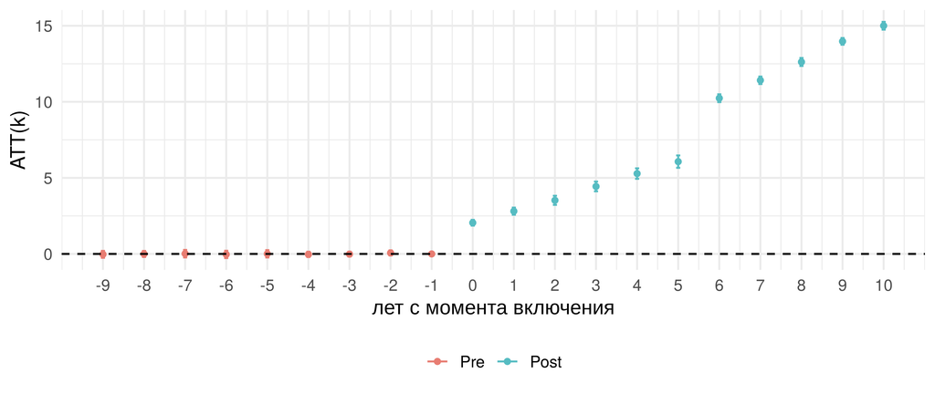

## Как читать вывод `aggte()`

- Вывод R
- С пояснениями

```
type = "simple"
  ATT    Std. Error     [ 95%  Conf. Int.]
 6.56         0.152       6.27        6.86 *

type = "dynamic"
Overall summary of ATT's based on event-study/dynamic aggregation:
  ATT    Std. Error     [ 95%  Conf. Int.]
 7.95        0.0681       7.81        8.08 *
Dynamic Effects:
 Event time Estimate Std. Error [95% Simult.  Conf. Band]
         -3  -0.0130     0.0541        -0.169       0.143
         -2   0.0663     0.0583        -0.102       0.235
         -1   0.0000         NA            NA          NA
          0   2.0502     0.0660         1.860       2.241 *
          1   2.8101     0.0812         2.576       3.045 *
          2   3.5239     0.1040         3.224       3.824 *
          5   6.0682     0.1411         5.661       6.475 *
          6  10.2376     0.0892         9.980      10.495 *
          7  11.4142     0.0852        11.168      11.660 *
         10  14.9992     0.0890        14.742      15.256 *
```

1 · simple

Среднее всех ATT(g,t) после включения, взвешенное по размеру когорт: 6.56 при истине 6.53

2 · Event time

$e = t - g$, лет с включения. $e = -1$ — база (0, `NA`); $e < 0$ — предтренды по событийному времени

3 · Overall в dynamic

Среднее ATT(e) по $e \ge 0$ с **равными** весами по $e$ — другой эстиманд: 7.95, а не 6.56

4 · состав

$e = 6 \ldots 10$ есть только у когорты 2005 (её эффект втрое больше): скачок от $e = 5$ к $e = 6$ — смена состава, а не динамика. Лекарство — `balance_e`

5 · ошибки

Бутстрэп по единицам; `aggte()` учитывает, что веса когорт **оценены**, — при разнородных эффектах это расширяет интервал

6 · сигналы беды

Overall из `dynamic` выдают за `simple`; хвосты $e$ с одной когортой рисуют как «нарастание»; $e < 0$ заметно отличаются от нуля

## Как писать результат

шаблон

«По оценке Callaway–Sant’Anna (контроль — никогда не обработанные, база $g - 1$, дважды робастная оценка, бутстрэп по единицам) средний эффект на обработанных составил **6.56** (s.e. 0.15; 95 % ДИ [6.27; 6.86]). Совместный предтест параллельных трендов не отвергает нулевую гипотезу (p = 0.59). Эффект нарастает с длительностью воздействия: от 2.05 в год включения до 6.07 через пять лет. TWFE на тех же данных даёт 1.92 из-за сравнений с уже обработанными.»

- Обязательно: группа сравнения, базовый период, **тип агрегата** (simple / dynamic / group — разные эстиманды), тип ошибок
- Не писать «эффект политики = X» без агрегата; не показывать хвосты ATT(e), где осталась одна когорта, как динамику эффекта

## Sun–Abraham и импутация

```r
sa <- feols(y ~ sunab(g, year) | id + year, data = sim |> mutate(g = ifelse(g == 0, 10000, g)),
            cluster = ~id)                              # никогда не обработанные: g = ∞
imp <- did_imputation(data = sim |> mutate(gvar = ifelse(g == 0, NA, g)),
                      yname = "y", gname = "gvar", tname = "year", idname = "id")
tibble(метод = c("истина", "TWFE", "Callaway–Sant'Anna", "Sun–Abraham", "импутация (BJS)"),
       ATT = c(true_att, coef(twfe)["d"], aggte(cs, type = "simple")$overall.att,
               summary(sa, agg = "ATT")$coeftable["ATT", 1], imp$estimate)) |>
  mutate(ATT = round(ATT, 2))
```

| метод | ATT |
| --- | --- |
| истина | 6.53 |
| TWFE | 1.92 |
| Callaway–Sant’Anna | 6.56 |
| Sun–Abraham | 6.56 |
| импутация (BJS) | 6.55 |

Три современных метода дают ≈ 6.5 — истину. TWFE — 1.9. Разница целиком объясняется запрещёнными сравнениями.

## Как читать вывод `sunab()`

- Вывод R
- С пояснениями

```
Standard-errors: Clustered (id)
          Estimate Std. Error  t value  Pr(>|t|)
year::-3 -0.012953     0.0519  -0.2498   0.80282
year::-2  0.066295     0.0588   1.1276   0.25993
year::0   2.050190     0.0532  38.5082 < 2.2e-16 ***
year::1   2.810061     0.0571  49.2352 < 2.2e-16 ***
year::2   3.523854     0.0540  65.2474 < 2.2e-16 ***
year::5   6.068195     0.0551 110.1230 < 2.2e-16 ***
year::6  10.237623     0.0874 117.1193 < 2.2e-16 ***
year::7  11.414192     0.0846 134.8491 < 2.2e-16 ***
```

```
    Estimate Std. Error t value  Pr(>|t|)
ATT     6.56     0.0432     152 < 2.2e-16 ***
```

1 · `year::k`

Относительное время $k = t - g$, усреднённое по когортам с весами их долей. $k = -1$ — база (`ref.p = -1`), строки нет

2 · никогда не обработанные

Закодированы $g = 10000$ (вне диапазона лет): `sunab()` сам берёт их как контрольную когорту

3 · сверка

Коэффициенты совпадают с `aggte(type = "dynamic")`: обе модели насыщены по «когорта × $k$» и имеют общую базу

4 · `agg = "ATT"`

Среднее всех пост-ячеек «когорта × $k$» с весами по числу наблюдений: 6.56 — как `simple` у Callaway–Sant’Anna

5 · ошибки

Кластер по `id` из `feols`. s.e. 0.043 против 0.152 у `aggte()`: тот учитывает, что веса когорт оценены

6 · сигналы беды

Никогда не обработанные оставлены с $g = 0$ — `sunab()` примет их за когорту; длинные $k$ держатся на одной когорте

## TWFE event study тоже ломается

```r
sim_es <- sim |> mutate(k_es = ifelse(g == 0, -1000, year - g))      # никогда: отдельная категория
twfe_es <- feols(y ~ i(k_es, ref = c(-1, -1000)) | id + year, data = sim_es, cluster = ~id)
iplot(list(twfe_es, sa), main = "Event study: TWFE против Sun–Abraham", xlab = "лет от включения",
      col = c(pal["coral"], pal["indigo"]), ci.width = 0, pt.join = TRUE)
legend("topleft", legend = c("TWFE", "Sun–Abraham"), col = c(pal["coral"], pal["indigo"]),
       pch = 16, bty = "n")
```

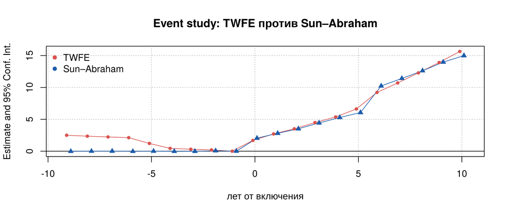

TWFE рисует «предтренды» величиной +2.5, которых нет, и занижает динамику. Sun–Abraham восстанавливает траекторию.

## RLMS: пенсионная реформа по когортам

Женщины 1964 г. р. и младше выходят на пенсию позже 55 лет — и каждая когорта на свой срок:

| Год рождения | Новый возраст | «Лишних» лет без пенсии |
| --- | --- | --- |
| ≤ 1963 | 55 | 0 (контроль) |
| 1964 / 1965 | 55.5 / 56.5 | 0.5 / 1.5 |
| 1966 / 1967 | 58 / 59 | 3 / 4 |
| ≥ 1968 | 60 | 5 |

Единицы — женщины, «время» — возраст; включение в 55 лет, но **интенсивность** разная по когортам. Оценим эффекты по группам когорт против дореформенных.

## Когортные event study по возрасту

- Результат
- Код

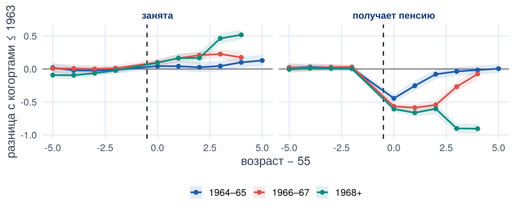

```r
pw <- rlms |>
  filter(female == 1, birth_year %in% 1958:1970, age %in% 50:60, year >= 2010) |>
  mutate(k = age - 55, g1 = as.integer(birth_year %in% 1964:1965),
         g2 = as.integer(birth_year %in% 1966:1967), g3 = as.integer(birth_year >= 1968))
rhs <- "~ i(k, g1, ref = -1) + i(k, g2, ref = -1) + i(k, g3, ref = -1) | birth_year + age"
fit_c <- function(y) feols(as.formula(paste(y, rhs)), data = pw, cluster = ~idind)
res <- map_dfr(c(`получает пенсию` = "pension", занята = "employed"),
               ~ tidy(fit_c(.x), conf.int = TRUE), .id = "исход") |>
  mutate(k = as.numeric(str_extract(term, "-?\\d+")),
         когорты = recode(str_extract(term, "g\\d"), g1 = "1964–65", g2 = "1966–67", g3 = "1968+"))
ggplot(res, aes(k, estimate, colour = когорты)) +
  geom_hline(yintercept = 0, colour = "grey50") + geom_vline(xintercept = -0.5, linetype = 2) +
  geom_ribbon(aes(ymin = conf.low, ymax = conf.high, fill = когорты), alpha = 0.12, colour = NA) +
  geom_line(linewidth = 1) + geom_point(size = 2) + facet_wrap(~ исход) +
  labs(x = "возраст − 55", y = "разница с когортами ≤ 1963", colour = NULL, fill = NULL)
```

## Что получает TWFE на тех же данных

```r
new_age <- c(`1964` = 55.5, `1965` = 56.5, `1966` = 58, `1967` = 59)        # остальные: 55 или 60
pw <- pw |> mutate(
  new_age = coalesce(new_age[as.character(birth_year)], ifelse(birth_year <= 1963, 55, 60)),
  d = as.integer(age >= 55 & age < new_age))          # «сейчас без пенсии из-за реформы»
etable(feols(pension ~ d | idind + year, pw, cluster = ~idind),
       feols(employed ~ d | idind + year, pw, cluster = ~idind), fitstat = ~ n)
```

|  | feols(pension ~.. | feols(employed.. |
| --- | --- | --- |
| Dependent Var.: | pension | employed |
| d | -0.191*** (0.012) | 0.046*** (0.011) |
| _______________ | _________________ | ________________ |
| S.E.: Clustered | by: idind | by: idind |
| Observations | 16,598 | 16,609 |

- −0.19 по пенсии при когортных −0.5…−0.9; +0.05 по занятости при когортных до +0.5
- Воздействие здесь ещё и **выключается** (достигли нового возраста): TWFE сравнивает тех, у кого оно прошло, с теми, у кого идёт. Выход — `DIDmultiplegt` или явные когортные оценки

## Чувствительность к предтрендам: `HonestDiD`

Rambachan & Roth: вместо «предтренды равны нулю» — «после включения нарушение параллельности не больше, чем $M \times$ самое большое нарушение до». Для каждого $M$ — доверительное множество эффекта.

```r
library(HonestDiD)      # remotes::install_github("asheshrambachan/HonestDiD")
es_w <- feols(employed ~ i(k, g3, ref = -1) | birth_year + age, data = pw, cluster = ~idind)
b <- coef(es_w); V <- vcov(es_w)
pre <- grep("^k::-", names(b)); post <- grep("^k::[0-9]", names(b)); idx <- c(pre, post)
createSensitivityResults_relativeMagnitudes(
  betahat = b[idx], sigma = V[idx, idx], numPrePeriods = length(pre),
  numPostPeriods = length(post), Mbarvec = c(0.5, 1, 1.5, 2))
```

# Как ошибаются

## Шесть ошибок со staggered DiD (1/2)

Нажмите на карточку:

ошибка 1

### TWFE с одним $D_{it}$

При разновременном включении — и ни одной проверки гетерогенности

**Как правильно:** Сравнить с Callaway–Sant’Anna, Sun–Abraham, импутацией: расходятся — эффекты гетерогенны, TWFE нельзя доверять

ошибка 2

### TWFE event study

Event study на TWFE с биннингом, который сам создаёт предтренды

**Как правильно:** Динамический агрегат `aggte(type = "dynamic")` или `sunab()` — event study без запрещённых сравнений

ошибка 3

### Плохой контроль

«Никогда не обработанные» — регионы, которые отличаются от остальных настолько, что не годятся в контроль

**Как правильно:** Назвать группу сравнения; `control_group = "notyettreated"` — сравнивать с ещё не обработанными

## Шесть ошибок со staggered DiD (2/2)

ошибка 4

### Выключение

Невключающееся воздействие (включили — выключили) оценивается методами для включающегося

**Как правильно:** `DIDmultiplegt` или явные когортные оценки

ошибка 5

### Один агрегат

Агрегат «simple» выдают за эффект политики, не показав динамику и когорты

**Как правильно:** Показать динамический и когортный агрегаты: каждый — отдельный эстиманд

ошибка 6

### Только p-value

Обсуждение предтрендов сводится к p-value без границ `HonestDiD`

**Как правильно:** Границы `HonestDiD`: при каком $\bar M$ эффект остаётся по знаку

## Чек-лист

- Нарисована карта включения (`panelView`): кто, когда, навсегда ли
- Названа группа сравнения: никогда / ещё не обработанные
- Оценены $ATT(g, t)$ и показаны динамический и когортный агрегаты
- Сравнение с TWFE и объяснение расхождения
- Чувствительность к предтрендам ($\bar M$)
- Кластер по единице назначения; при малом числе единиц — bootstrap

# Мини-задача

## Задание к следующему занятию

1. Повторите когортный анализ для **мужчин** (1959–1965 г. р., включение в 60 лет). Где эффект на занятость сильнее — у мужчин или женщин? Почему?
2. В симуляции сделайте эффекты **одинаковыми** для когорт и постоянными во времени. Совпадут ли TWFE и Callaway–Sant’Anna? Затем сделайте эффект у ранней когорты **убывающим** — что станет с TWFE?
3. Оцените когортные эффекты реформы на самооценку здоровья и `life_sat`. Есть ли «штраф» за работу без пенсии?
4. Установите `HonestDiD` и постройте границы для когорты 1968+ при $\bar M \in \{0.5, 1, 2\}$

# Литература

## Что прочитать

- Goodman-Bacon A. (2021). Difference-in-Differences with Variation in Treatment Timing. *J. Econometrics*
- Callaway B., Sant’Anna P. (2021). Difference-in-Differences with Multiple Time Periods. *J. Econometrics*
- Sun L., Abraham S. (2021). Estimating Dynamic Treatment Effects in Event Studies with Heterogeneous Treatment Effects. *J. Econometrics*
- Borusyak K., Jaravel X., Spiess J. (2024). Revisiting Event-Study Designs: Robust and Efficient Estimation. *REStud*
- de Chaisemartin C., D’Haultfœuille X. (2020). Two-Way Fixed Effects Estimators with Heterogeneous Treatment Effects. *AER*
- Baker A., Larcker D., Wang C. (2022). How Much Should We Trust Staggered DiD Estimates? *JFE* — симуляции, как здесь; Roth J. et al. (2023) — обзор

Каузальный анализ в R · RLMS-HSE · К. Аванесян

← К программе курса